# Ejercicios 3

[figure not shown]

Supongamos que tenemos un fichero de texto encuesta con los datos de una encuesta realizada por un agricultor de rábanos. Dicho fichero recoge información de las preferencias de los consumidores acerca de las distintas variedades.

- Cada línea del fichero tiene el siguiente formato: $$ nombre\_cliente \ - \ variedad\_de\_rábano $$

#### 1 Ejercicio

El fichero dispone de casi 700 opiniones de usuarios. Abre el fichero para ver el contenido.

1. Consulta el directorio de trabajo de Ipython. Para ello ejecuta el comando mágico `%pwd` en la siguiente celda.
2. Descárgate el fichero encuesta en tu directorio de trabajo
3. Ábrelo con la instrucción **open**.
4. Realiza un print de las 10 primeras líneas del fichero. Utiliza un bucle **for** de 10 iteraciones para leer el contenido del fichero.

```python
ruta = './datos/radishsurvey.txt'
ruta
```

```
'./datos/radishsurvey.txt'
```

```python
# Sol:
```

#### 2 Ejercicio

Escribe una función llamada **clientes** que devuelva la lista de clientes que han votado por alguna variedad de rábanos.

1. Utiliza un bucle **for** para leer el contenido completo del fichero.
2. Usa la función **strip** para eliminar los saltos de línea.
3. Usa la función **split** para separar el nombre del cliente y la variedad de rábano
4. Utiliza la función **append** para añadir el nombre del cliente a una lista de clientes (previamente inicializada).
5. No te olvides de realizar un **return** para devolver el resultado.

**Nota**: El cliente número 15 en la lista es "Jonathan Rolph".

```python
# Sol:
```

#### 3 Ejercicio

El agricultor desea conocer el número total de votos que ha recibido la variedad de rábanos 'White Icicle'. Define una función denominada **votosWI** que calcula el dato pedido.

1. Utiliza una variable entera inicializada a 0 para almacenar el contador de votos.
2. Utiliza un bucle **for** para leer el contenido del fichero.
3. Usa la función **strip** para eliminar los saltos de línea.
4. Usa la función **split** para separar el nombre del cliente y la variedad de rábano
5. Usa la instrucción **if** para comprobar si la variedad de rábano es 'White Icicle'. En caso afirmativo suma 1 al contador de votos.
6. No te olvides de devolver el número de votos mediante la instrucción **return**

**Nota**: El resultado es: 59 votos.

```python
# Sol:
```

#### 4 Ejercicio

Generaliza la función anterior y define una función que calcule el número de votos que ha recibido una variedad cualquiera de rábanos.

- Define una función llamada **votos** que reciba como parámetro una variedad de rábano y devuelva la cantidad de votos.

**Nota**: La variedad *Snow Belle* ha recibido 58 votos.

```python
# Sol:
```

#### 5 Ejercicio

Define una función llamada **clientesPorVariedad** que reciba como parámetro una variedad de rábano y devuelva la lista de clientes que han votado por esa variedad. Ten en cuenta que esta función es casi idéntica que la anterior.

**Nota**: Prueba con la variedad de rábanos *White Icicle*. La solución será una lista donde los primeros elementos son:

['Luke Komine', 'Bailey Derrington', 'Tyler Forbes', 'Gianfranco Cremonesi', 'Tao Hsiao', ...]

```python
'  oo'.lstrip()
```

```
'oo'
```

```python
# Sol:
```

#### 6 Ejercicio

Al agricultor le gustaría conocer el número de votos recibidos por cada variedad. Define una función llamada **votos_por_variedad** que devuelva la información del número de votos por variedad. Usa un diccionario para almacenar esa información. La clave del diccionario es la variedad y el valor es un entero que representa el número de votos.

1. Crea un diccionario vacío.
2. Utiliza un bucle **for** para leer el contenido del fichero.
3. Usa la función **strip** para eliminar los saltos de línea.
4. Usa la función **split** para separar el nombre del cliente y la variedad de rábano
5. Usa la instrucción **if** para comprobar si la variedad está en el diccionario. En caso afirmativo suma 1 al valor. En caso contrario añade una nueva variedad al diccionario.
6. No te olvides de devolver el diccionario pedido mediante la instrucción **return**.

```python
# Sol:
```

Observa la solución. Si te das cuenta, en el diccionario aparecen variedades con minúscula y mayúscula ('white icicle' y 'White Icicle'). También aparecen variedades con espacios en blanco al principio. Un desastre de datos!.

Tenemos que hacer una limpieza de datos para solventar el problema anterior.

- Corrige la función anterior haciendo uso de la función **strip** y **title** en cada variedad de rábanos.

El diccionario generado es el siguiente:

{'April Cross': 72, 'Bunny Tail': 72, 'Champion': 76, 'Cherry Belle': 1, 'Cherry Belle': 57, 'Daikon': 63, 'French Breakfast': 72, 'Plum Purple': 1, 'Plum Purple': 56, 'Red King': 56, 'Sicily Giant': 1, 'Sicily Giant': 56, 'Snow Belle': 63, 'White Icicle': 65}

Pero aún salen cosas raras. Fíjate en las variedades 'Sicily Giant' y 'Sicily Giant'. Deberían ser la misma variedad.

- Usa el método **replace** para sustituir las apariciones de dos espacios en blanco por un solo espacio en blanco.

```python
# Sol:
```

#### 7 Ejercicio

El agricultor desea guardar en un fichero de texto la lista de las variedades junto con el número de votos obtenidos.

- Abre un fichero llamado **resultado.txt** en modo escritura
- Invoca la función **votos_por_variedad** para obtener el diccionario que contiene el número de votos por variedad.
- Utiliza la instrucción **for** para iterar sobre los elementos del diccionario y escribir en el fichero.
- Cierra el fichero.

```python
# Sol:
```

#### Esto no es un ejercicio. Solo ejecuta a ver qué sale ...

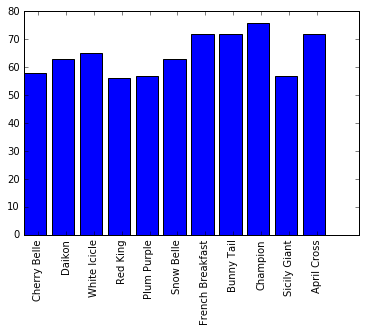

```python
import matplotlib.pyplot as plt
import numpy as np

%pylab inline

d =  votos_por_variedad()
names = d.keys()
votes = d.values()           # eje y

x = np.arange(len(votes))    # eje x
plt.bar(x, votes)            # pinto diagrama de barras

plt.xticks(x+ 0.5, names, rotation=90) ;      # etiqueto el eje x con los nombres de las variedades
```

## Referencias

- [Working with Strings](http://esparta.github.io/python-data-intro/core/strings.html)